# HW 6: Gaslighting dataset

Melanie Kos

# Instructions

1. State a hypothesis about the gaslighting dataset
2. Develop your processing pipeline and justify steps, etc.
3. Analyze your data, report relevant statistics and visualization(s)
4. State your conclusions

# Load in both datasets and see what variables exist

```r
load(url("https://github.com/Reilly-ConceptsCognitionLab/reillylab_publicdata/blob/main/lookup_Jul25.rda?raw=true"))
lookup_db <- lookup_Jul25
colnames(lookup_db)
```

```
##  [1] "word"                    "emo_anger"
##  [3] "emo_anger_rescale"       "emo_anxiety"
##  [5] "emo_anxiety_rescale"     "emo_arousal_b24"
##  [7] "emo_arousal_b24_rescale" "emo_boredom"
##  [9] "emo_boredom_rescale"     "emo_confusion"
## [11] "emo_confusion_rescale"   "emo_excitement"
## [13] "emo_excitement_rescale"  "emo_guilt"
## [15] "emo_guilt_rescale"       "emo_happiness"
## [17] "emo_happiness_rescale"   "emo_intensity"
## [19] "emo_intensity_recale"    "emo_sadness"
## [21] "emo_sadness_rescale"     "emo_trust"
## [23] "emo_trust_rescale"       "emo_valence_b24"
## [25] "emo_valence_b24_rescale" "lex_AoA"
## [27] "lex_AoA_rescale"         "lex_freqlg10"
## [29] "lex_freqlg10_rescale"    "lex_n_morphemes"
## [31] "lex_n_senses"            "lex_n_senses_rescale"
## [33] "phon_n_lett"             "phon_nsyll"
## [35] "sem_auditory"            "sem_auditory_rescale"
## [37] "sem_cnc_b24"             "sem_cnc_b24_rescale"
## [39] "sem_cnc_v2013"           "sem_cnc_v2013_rescale"
## [41] "sem_diversity"           "sem_diversity_rescale"
## [43] "sem_neighbors"           "sem_neighbors_rescale"
## [45] "sem_visual"              "sem_visual_rescale"
```

```r
# Load gaslight corpus
load(url("https://github.com/Reilly-ConceptsCognitionLab/reillylab_publicdata/blob/main/gaslight.rda?raw=true"))
colnames(gaslight)
```

```
## [1] "X"                   "ID"                  "gd_adult_definition"
## [4] "gd_adult_story"      "Ever_Gaslit"         "Gender"
## [7] "Age"
```

```r
gaslight$Gender <- as.factor(gaslight$Gender)
gaslight$ID <-  as.factor(gaslight$ID)
gaslight$Ever_Gaslit <- as.factor(gaslight$Ever_Gaslit)

my_tab <- table(gaslight$Ever_Gaslit, gaslight$Gender)
print(my_tab)
```

```
##
##           Female Male
##   No    4    163   60
##   Yes  19    654  134
```

```r
summary(my_tab)
```

```
## Number of cases in table: 1034
## Number of factors: 2
## Test for independence of all factors:
##  Chisq = 11.31, df = 2, p-value = 0.003499
```

Okay, so the gaslighting data is from 1034 individuals who reported their age, gender, if they had ever been gaslit, and provided a definition and examples of gaslighting.

# Hypothesis about gaslighting dataset

I hypothesize that we will see 1) gender differences in the data, such that emotional intensity of the gaslight story that is shared will be lower for males as compared to females. I also expect that there will be 2) age differences in the data, such that the emotional intensity of the gaslight story will be lower for older participants as compared to younger. However, I expect that 3) people that report being gaslit will have higher emotional intensity. Further, 4) history of being gaslit will moderate the gender and age effects.

# Develop processing pipeline

First, going to clean up the gaslight data using my cleaning genie.

```r
melanie_genie <- function(data, # Input data
                          text_col = NULL, # Indicate name of text column for a df input
                          id_col = NULL, # Indicate name of subject ID column for a df input
                          lemmatize = TRUE, #Lemmatize words on or off
                          omit_stops = TRUE, # Remove stops
                          remove_numbers = TRUE, # Remove numbers
                          remove_number_words = TRUE, # Remove written out numbers
                          remove_roman = TRUE, # Remove roman numerals
                          strip_possessives = TRUE, # Amend singular and plural possessives
                          normalize_abbrev = TRUE, # Replace common abbreviations with full word
                          dash_mode = c("prefix_merge", "split", "remove"),
                          # Prefix_merge = merge common list of common prefixes on hyphen (ie re-do becomes redo, well-being becomes well being)
                          # Split = all hyphens become spaces (ie re-do becomes re do, well-being becomes well being)
                          # Remove = all hyphens are removed (ie re-do becomes redo, well-being becomes wellbeing)
                          return_base_text = FALSE) # Return the fully cleaned base text along with two df outputs

{

  dash_mode <- match.arg(dash_mode)

  library(dplyr)
  library(tidyr)
  library(stringr)
  library(stringi)
  library(textstem)
  library(tidytext)

  ###############################################################
  ### Data type check; if data is a df, indicate the text columns
  ###############################################################
  if (is.data.frame(data)) {

  if (is.null(text_col)) {
    stop("If data is a dataframe, you must supply text column names")}

  if (!text_col %in% names(data)) {
    stop(paste("Column", text_col, "not found in df"))}

  x <- as.character(data[[text_col]])
  if (is.null(id_col)) {
  id_values <- seq_len(nrow(data))
} else {
  if (!id_col %in% names(data))
    stop(paste("Column", id_col, "not found in dataframe"))

  id_values <- data[[id_col]]
}

df_base <- tibble(ID = id_values, id_row_orig = seq_along(x), text = x)

} else {

  # Character vector input
  x <- as.character(data)
  df_base <- tibble(ID = seq_along(x), id_row_orig = seq_along(x), text = x)
}

  # Load stopword and replacement lists from github
  load(url("https://github.com/Reilly-ConceptsCognitionLab/reillylab_publicdata/blob/main/Temple_stops25.rda?raw=true"))
  load(url("https://github.com/Reilly-ConceptsCognitionLab/reillylab_publicdata/blob/main/replacements_25.rda?raw=true"))
  ################################
  ### Below modules are always on:
  ################################

  # Normalize all text to UTF-8 encoding
  utf8_normalize <- function(x) {
    tryCatch(stringi::stri_enc_toutf8(as.character(x), is_unknown_8bit = TRUE, validate = TRUE),
             error = function(e)
               stringi::stri_encode(as.character(x), to = "UTF-8"))
  }

  # Remove any new lines, tabs, returns, etc.
  strip_control_characters <- function(x) {
    stringi::stri_replace_all_regex(x, "[\\p{C}]+", " ")
  }

  # Normalize apostrophes and quotation marks
  normalize_quotes <- function(x) {
    x <- str_replace_all(x, "[\u2018\u2019\u2032\u0027\u00b4\u201b]","'") # Manage apostrophes to be straight
    x <- str_replace_all(x,"[\u201c\u201d\u0022\u2033\u02dd\u201f\u201e]","[\u0022]") # Manage quotation marks to be straight
    x
  }

  #####################################
  ### Below modules are toggled on/off:
  #####################################

  # Normalize abbreviations (toggle on/off)
  normalize_abbrev_module <- function(x) {
    # Apply contractions replacement (only for non-NA values) (search x for contractions, replace with replacement phrase)
    x <- str_replace_all(x, setNames(replacements_25$replacement, replacements_25$word))

    # Manual change of popular abbreviations...
    x <- gsub("and/or", "and or", x)
    x <- gsub("\\bi\\.e\\.(?=\\W|$)", "that is", x, perl = TRUE)
    x <- gsub("\\betc\\.(?=\\W|$)", "etcetera", x, perl = TRUE)
    x <- gsub("vis-a-vis(?=\\W|$)", "visavis", x, perl = TRUE)
    x <- gsub("\\be\\.g\\.(?=\\W|$)", "for example", x, perl = TRUE)
    x <- gsub("\\bMr\\.(?=\\W|$)", "mister", x, perl = TRUE)
    x <- gsub("\\bMrs\\.(?=\\W|$)", "missus", x, perl = TRUE)
    x <- gsub("\\bMs\\.(?=\\W|$)", "miss", x, perl = TRUE)
    x <- gsub("\\bSr\\.(?=\\W|$)", "senior", x, perl = TRUE)
    x <- gsub("\\bJr\\.(?=\\W|$)", "junior", x, perl = TRUE)
    x <- gsub("\\bSte\\.(?=\\W|$)", "suite", x, perl = TRUE)
    x <- gsub("\\bCapt\\.(?=\\W|$)", "captain", x, perl = TRUE)
    x <- gsub("\\bProf\\.(?=\\W|$)", "professor", x, perl = TRUE)
    x <- gsub("\\bRev\\.(?=\\W|$)", "reverend", x, perl = TRUE)
    x <- gsub("\\bSt\\.(?=\\s+[A-Z])", "saint", x, perl = TRUE) # Saint (religious / place names), usually followed by capital letter for name
    x <- gsub("\\bSt\\.(?=\\s*[a-z0-9]|\\W|$)", "street", x, perl = TRUE) # Street (addresses), usually followed by non-capital letter or punctuation
    x <- gsub("\\bDr\\.(?=\\s+[A-Z])", "doctor", x, perl = TRUE) # Doctor, usually followed by capital letter for name
    x <- gsub("\\bDr\\.(?=\\s*[a-z0-9]|\\W|$)", "drive", x, perl = TRUE) # Drive (addresses), usually followed by non-capital letter or punctuation
    x
  }

  # Normalize singular and plural possessives (toggle on/off)
  strip_possessives_module <- function(x) {
    x <- gsub("'s\\b", "", x) # Singular possessive (so no additional s at end of word)
    x <- gsub("s'\\b", "s", x) # Plural possessives (so no additional ss at end of word)
    x
  }

  # Remove roman numerals for chapters, etc. AND other numerals anywhere else (toggle on/off)
  remove_roman_module <- function(x) {
    # Remove chapter, section numerals
    x <- gsub("\\b(?i:(chapter|section|act|book|part))\\s+(?i:[ivxlcdm]+)(st|nd|rd|th)?(?=[[:punct:]]|\\s|$)", "", x, perl = TRUE)

    # Remove any remaining Roman numerals anywhere in text
    x <- gsub("\\b(?i:[ivxlcdm]+)(st|nd|rd|th)?\\b", "", x,perl = TRUE)
    x
  }

  # Remove all numeric numbers and suffix for written numbers (toggle on/off)
  remove_numbers_module <- function(x) {
    x <- gsub("\\b(\\d+)(st|nd|rd|th)\\b", "\\1", x, perl = TRUE)
    x <- gsub("[[:digit:]]", "", x)
    x
  }


  # Remove all written out numbers (toggle on/off)
  remove_number_words_module <- function(words) {
    number_stems <- "\\b(zero|one|two|three|four|five|six|seven|eight|nine|ten|eleven|twelve|thirteen|fourteen|fifteen|sixteen|seventeen|eighteen|nineteen|twenty|thirty|forty|fifty|sixty|seventy|eighty|ninety|hundred|thousand|million|billion)\\b"
    ifelse(str_detect(words, number_stems), NA_character_, words)
  }


  # Hyphen/dash module, 3 potential modes (also defined above):
  # Prefix_merge = merge common list of common prefixes on hyphen (ie re-do becomes redo, well-being becomes well being)
  # Split = all hyphens become spaces (ie re-do becomes re do, well-being becomes well being)
  # Remove = all hyphens are removed and squished (ie re-do becomes redo, well-being becomes wellbeing)
  dash_mode_module <- function(x, mode) {
    if (mode == "prefix_merge") {
      x <- gsub(
        "\\b(re|co|de|ex|pro|anti|non|self|pre|post|un|trans|quasi|dis|im|auto|hyper|neo|under|over|sub|mis|poly|mal|in|inter|com|bi|counter|be|good|to|with|a|al|be|for|fore|out)\\s*-\\s*",
        "\\1", x, ignore.case = TRUE, perl = TRUE)
      x <- gsub("(?<=\\p{L})-(?=\\p{L})", " ", x, perl = TRUE) # Any other words without above prefixes become two words
    }
    if (mode == "split") {
      x <- gsub("-", " ", x) # Split all hyphens into two words
    }
    if (mode == "remove") {
      x <- gsub("-", "", x) # Split all hyphens into one word
    }
    x
  }

  # Lemmatization module (toggle on/off)
  lemmatize_module <- function(text_vector) {
    textstem::lemmatize_strings(text_vector) # Note lemmatize_strings usage
  }

  # Remove stop words as defined in Temple_stops25 (toggle on/off, can also change stop word list...)
  omit_stops_module <- function(words) {
    stopwords <- tolower(Temple_stops25$word)
    ifelse(words %in% stopwords, NA_character_, words)
  }

  #############################################
  # Actual cleaning begins...
  #############################################
  df_base$text <- utf8_normalize(df_base$text)
  df_base$text <- strip_control_characters(df_base$text)
  df_base$text <- normalize_quotes(df_base$text)

  if (normalize_abbrev) {
    df_base$text <- normalize_abbrev_module(df_base$text)}

  if (strip_possessives) {
    df_base$text <- strip_possessives_module(df_base$text)}

  # Roman numeral removal BEFORE punctuation cleanup (so "I." "II." etc. are removed)
  if (remove_roman) {
    df_base$text <- remove_roman_module(df_base$text)}

  # Dash/hyphen handling
  df_base$text <- dash_mode_module(df_base$text, dash_mode)

  # Punctuation cleanup
  df_base$text <- gsub("\t|[[:punct:]]+", " ", df_base$text) # Remove tabs, punctuation, account for any missing spaces between punctuation

  # Lowercase and squish
  df_base$text <- str_to_lower(df_base$text) # Lowercase everything
  df_base$text <- str_squish(df_base$text) # Remove any empty spaces between words, line breaks, etc.

  # Digit removal and numeric suffix removal AFTER punctuation cleanup
  if (remove_numbers) {
    df_base$text <- remove_numbers_module(df_base$text)}

  # String-level lemmatization BEFORE tokenization
  if (lemmatize) {
    df_base$text <- lemmatize_module(df_base$text)}

  # Tokenization
  token_df <- df_base |>
    unnest_tokens(word_raw, text, drop = FALSE) |>
    mutate(id_row_postsplit = row_number(),
           word_lemma = word_raw)

  # Remove number words
  if (remove_number_words) {
    token_df <- token_df |>
      mutate(word_lemma = remove_number_words_module(word_lemma))}


  # Stopword toggle
  if (omit_stops) {
    token_df <- token_df |>
      mutate(word_clean = omit_stops_module(word_lemma))
  } else {
    token_df <- token_df |>
      mutate(word_clean = word_lemma)}

  # Remove single letters
  token_df <- token_df |>
    mutate(word_clean = ifelse(nchar(word_clean) <= 1, NA_character_, word_clean))

  # Counts
  token_df <- token_df |>
    mutate(word_lemma = ifelse(str_detect(word_lemma, "\\d"), NA_character_, word_lemma), # Make sure digits are removed
           word_clean = ifelse(str_detect(word_clean, "\\d"), NA_character_, word_clean)) |>
    group_by(ID, word_raw) |>
    mutate(n_raw = n()) |>
    ungroup() |>
    group_by(ID, word_clean) |>
    mutate(n_clean = ifelse(is.na(word_clean), NA_integer_, n())) |>
    ungroup()

  type_df <- token_df |>
    group_by(ID, word_raw, word_lemma, word_clean) |>
    summarise(n_raw = n(), .groups = "drop") |>
    left_join(token_df |>
      filter(!is.na(word_clean)) |>
        group_by(ID, word_raw) |>
        summarise(n_clean = n(), .groups = "drop"), by = c("ID","word_raw"))

  type_df <- type_df |>
  arrange(ID, desc(n_clean), desc(n_raw))


  # Return base text (fully cleaned string-level text) (toggle on/off)
  if (return_base_text) {
    list(base_text = df_base$text, token_df = token_df, type_df = type_df)
  } else {
    list(token_df = token_df, type_df  = type_df)
  }

}

gaslight_clean <- melanie_genie(gaslight, text_col = "gd_adult_story", id_col = "ID", dash_mode = "prefix_merge")
```

[output not shown]

```r
gaslight_token <- gaslight_clean$token_df
gaslight_type <- gaslight_clean$type_df
```

Now, going to merge my cleaned gaslight data token dataframe with the hypothesis’s variables of interest from original gaslight (gender, age, gaslight history) and database lookup (scales).

```r
# Adding back in variables of interest from original gaslight dataframe
my_gaslight <- gaslight_token |>
  left_join(gaslight |>
              dplyr::select(ID, Ever_Gaslit, Age, Gender))
# Adding in database lookup values
my_gaslight <- my_gaslight |>
  left_join(lookup_db, by = c("word_clean" = "word"))
print(my_gaslight)
```

```
## # A tibble: 83,051 × 57
##    ID    id_row_orig text  word_raw id_row_postsplit word_lemma word_clean n_raw
##    <fct>       <int> <chr> <chr>               <int> <chr>      <chr>      <int>
##  1 814             1 the … the                     1 the        <NA>           7
##  2 814             1 the … student                 2 student    student        1
##  3 814             1 the … be                      3 be         <NA>           5
##  4 814             1 the … harass                  4 harass     harass         1
##  5 814             1 the … by                      5 by         <NA>           1
##  6 814             1 the … a                       6 a          <NA>           1
##  7 814             1 the … customer                7 customer   customer       5
##  8 814             1 the … she                     8 she        <NA>           4
##  9 814             1 the … say                     9 say        say            1
## 10 814             1 the … stuff                  10 stuff      stuff          1
## # ℹ 83,041 more rows
## # ℹ 49 more variables: n_clean <int>, Ever_Gaslit <fct>, Age <int>,
## #   Gender <fct>, emo_anger <dbl>, emo_anger_rescale <dbl>, emo_anxiety <dbl>,
## #   emo_anxiety_rescale <dbl>, emo_arousal_b24 <dbl>,
## #   emo_arousal_b24_rescale <dbl>, emo_boredom <dbl>,
## #   emo_boredom_rescale <dbl>, emo_confusion <dbl>,
## #   emo_confusion_rescale <dbl>, emo_excitement <dbl>, …
```

## Pull variables

Pulling just the words, emotional intensity values (rescaled), gender, age, and history of being gaslit variables, removing NAs and blanks:

```r
analysis_df <- my_gaslight |>
  dplyr::select(ID, word_clean, emo_intensity_recale, Gender, Age, Ever_Gaslit) |>
  dplyr::filter(!is.na(word_clean), word_clean != "",
                !is.na(emo_intensity_recale), emo_intensity_recale != "",
                !is.na(Gender), Gender != "",  # Blanks in df for some / not NAs
                !is.na(Age), Age != "",
                !is.na(Ever_Gaslit), Ever_Gaslit != "") |>
  dplyr::mutate(Gender = factor(Gender), Ever_Gaslit = factor(Ever_Gaslit), Age = as.numeric(Age))
analysis_df
```

```
## # A tibble: 42,219 × 6
##    ID    word_clean emo_intensity_recale[,1] Gender   Age Ever_Gaslit
##    <fct> <chr>                         <dbl> <fct>  <dbl> <fct>
##  1 814   student                       3.08  Female    19 No
##  2 814   harass                        8.70  Female    19 No
##  3 814   customer                      0.709 Female    19 No
##  4 814   say                           0.155 Female    19 No
##  5 814   stuff                         0.133 Female    19 No
##  6 814   back                          0.133 Female    19 No
##  7 814   customer                      0.709 Female    19 No
##  8 814   make                          0.155 Female    19 No
##  9 814   customer                      0.709 Female    19 No
## 10 814   much                          0.133 Female    19 No
## # ℹ 42,209 more rows
```

```r
n_distinct(analysis_df$ID)
```

```
## [1] 985
```

Cleanup has left us with 985 subjects for analyses.

## H1: Gender and emotional intensity

First, let’s look at gender differences in emotional intensity:

```r
library(lmerTest)
H1 <- lmer(emo_intensity_recale ~ Gender + (1 | ID), data = analysis_df)
summary(H1)
```

```
## Linear mixed model fit by REML. t-tests use Satterthwaite's method [
## lmerModLmerTest]
## Formula: emo_intensity_recale ~ Gender + (1 | ID)
##    Data: analysis_df
##
## REML criterion at convergence: 174506.9
##
## Scaled residuals:
##     Min      1Q  Median      3Q     Max
## -1.0391 -0.5832 -0.4694  0.1196  4.2199
##
## Random effects:
##  Groups   Name        Variance Std.Dev.
##  ID       (Intercept) 0.0774   0.2782
##  Residual             3.6006   1.8975
## Number of obs: 42219, groups:  ID, 985
##
## Fixed effects:
##              Estimate Std. Error        df t value Pr(>|t|)
## (Intercept)   1.27480    0.01492 911.38004  85.465   <2e-16 ***
## GenderMale    0.05928    0.03444 923.80973   1.721   0.0856 .
## ---
## Signif. codes:  0 '***' 0.001 '**' 0.01 '*' 0.05 '.' 0.1 ' ' 1
##
## Correlation of Fixed Effects:
##            (Intr)
## GenderMale -0.433
```

So there are no significant differences between males and females in the emotional intensity of their gaslight stories.

## H2: Age and emotional intensity

Now, let’s look at age differences in emotional intensity:

```r
H2 <- lmer(emo_intensity_recale ~ Age + (1 | ID), data = analysis_df)
summary(H2)
```

```
## Linear mixed model fit by REML. t-tests use Satterthwaite's method [
## lmerModLmerTest]
## Formula: emo_intensity_recale ~ Age + (1 | ID)
##    Data: analysis_df
##
## REML criterion at convergence: 174512.2
##
## Scaled residuals:
##     Min      1Q  Median      3Q     Max
## -1.0410 -0.5821 -0.4698  0.1207  4.2174
##
## Random effects:
##  Groups   Name        Variance Std.Dev.
##  ID       (Intercept) 0.07779  0.2789
##  Residual             3.60053  1.8975
## Number of obs: 42219, groups:  ID, 985
##
## Fixed effects:
##              Estimate Std. Error        df t value Pr(>|t|)
## (Intercept) 1.158e+00  1.218e-01 7.646e+02   9.511   <2e-16 ***
## Age         6.484e-03  6.136e-03 7.574e+02   1.057    0.291
## ---
## Signif. codes:  0 '***' 0.001 '**' 0.01 '*' 0.05 '.' 0.1 ' ' 1
##
## Correlation of Fixed Effects:
##     (Intr)
## Age -0.994
```

There are no significant differences in the emotional intensity of participants’ gaslighting stories associated with age.

## H3: History of being gaslit and emotional intensity

```r
H3 <- lmer(emo_intensity_recale ~ Ever_Gaslit + (1 | ID), data = analysis_df)
summary(H3)
```

```
## Linear mixed model fit by REML. t-tests use Satterthwaite's method [
## lmerModLmerTest]
## Formula: emo_intensity_recale ~ Ever_Gaslit + (1 | ID)
##    Data: analysis_df
##
## REML criterion at convergence: 174509
##
## Scaled residuals:
##     Min      1Q  Median      3Q     Max
## -1.0407 -0.5829 -0.4703  0.1216  4.2192
##
## Random effects:
##  Groups   Name        Variance Std.Dev.
##  ID       (Intercept) 0.07781  0.279
##  Residual             3.60053  1.898
## Number of obs: 42219, groups:  ID, 985
##
## Fixed effects:
##                 Estimate Std. Error        df t value Pr(>|t|)
## (Intercept)      1.31038    0.02922 950.53682  44.852   <2e-16 ***
## Ever_GaslitYes  -0.03102    0.03292 941.22364  -0.942    0.346
## ---
## Signif. codes:  0 '***' 0.001 '**' 0.01 '*' 0.05 '.' 0.1 ' ' 1
##
## Correlation of Fixed Effects:
##             (Intr)
## Ever_GsltYs -0.888
```

There are no significant differences in the emotoional intensity of participants’ gaslighting stories associated with their histories of ever being gaslit.

## H4-5: Interaction with gaslighting history

```r
H4 <- lmer(emo_intensity_recale ~ Age*Ever_Gaslit + (1 | ID), data = analysis_df)
summary(H4)
```

```
## Linear mixed model fit by REML. t-tests use Satterthwaite's method [
## lmerModLmerTest]
## Formula: emo_intensity_recale ~ Age * Ever_Gaslit + (1 | ID)
##    Data: analysis_df
##
## REML criterion at convergence: 174522.8
##
## Scaled residuals:
##     Min      1Q  Median      3Q     Max
## -1.0402 -0.5820 -0.4705  0.1214  4.2190
##
## Random effects:
##  Groups   Name        Variance Std.Dev.
##  ID       (Intercept) 0.07809  0.2794
##  Residual             3.60047  1.8975
## Number of obs: 42219, groups:  ID, 985
##
## Fixed effects:
##                      Estimate Std. Error         df t value Pr(>|t|)
## (Intercept)          1.241383   0.256509 763.652518   4.840 1.58e-06 ***
## Age                  0.003496   0.012905 752.190449   0.271    0.787
## Ever_GaslitYes      -0.106331   0.291525 763.969339  -0.365    0.715
## Age:Ever_GaslitYes   0.003824   0.014673 753.746925   0.261    0.794
## ---
## Signif. codes:  0 '***' 0.001 '**' 0.01 '*' 0.05 '.' 0.1 ' ' 1
##
## Correlation of Fixed Effects:
##             (Intr) Age    Evr_GY
## Age         -0.993
## Ever_GsltYs -0.880  0.874
## Ag:Evr_GslY  0.874 -0.879 -0.994
```

```r
H5 <- lmer(emo_intensity_recale ~ Gender*Ever_Gaslit + (1 | ID), data = analysis_df)
summary(H5)
```

```
## Linear mixed model fit by REML. t-tests use Satterthwaite's method [
## lmerModLmerTest]
## Formula: emo_intensity_recale ~ Gender * Ever_Gaslit + (1 | ID)
##    Data: analysis_df
##
## REML criterion at convergence: 174514.5
##
## Scaled residuals:
##     Min      1Q  Median      3Q     Max
## -1.0388 -0.5832 -0.4697  0.1198  4.2211
##
## Random effects:
##  Groups   Name        Variance Std.Dev.
##  ID       (Intercept) 0.07771  0.2788
##  Residual             3.60053  1.8975
## Number of obs: 42219, groups:  ID, 985
##
## Fixed effects:
##                             Estimate Std. Error         df t value Pr(>|t|)
## (Intercept)                 1.294409   0.034135 930.621230  37.920   <2e-16 ***
## GenderMale                  0.059583   0.065948 977.476010   0.903    0.366
## Ever_GaslitYes             -0.024217   0.037959 925.861278  -0.638    0.524
## GenderMale:Ever_GaslitYes  -0.004329   0.077531 954.916597  -0.056    0.955
## ---
## Signif. codes:  0 '***' 0.001 '**' 0.01 '*' 0.05 '.' 0.1 ' ' 1
##
## Correlation of Fixed Effects:
##             (Intr) GndrMl Evr_GY
## GenderMale  -0.518
## Ever_GsltYs -0.899  0.465
## GndrMl:E_GY  0.440 -0.851 -0.490
```

And there is no interaction between individuals’ histories of being gaslit with neither age nor gender on the emotional intensity of their gaslight example stories…. Going back to the drawing board on this one, let’s look at a correlation matrix and try to sus out any patterns for at least one reportable result (sigh, cherry picking?).

## Correlation matrix

Let’s make a correlation matrix of the variables:

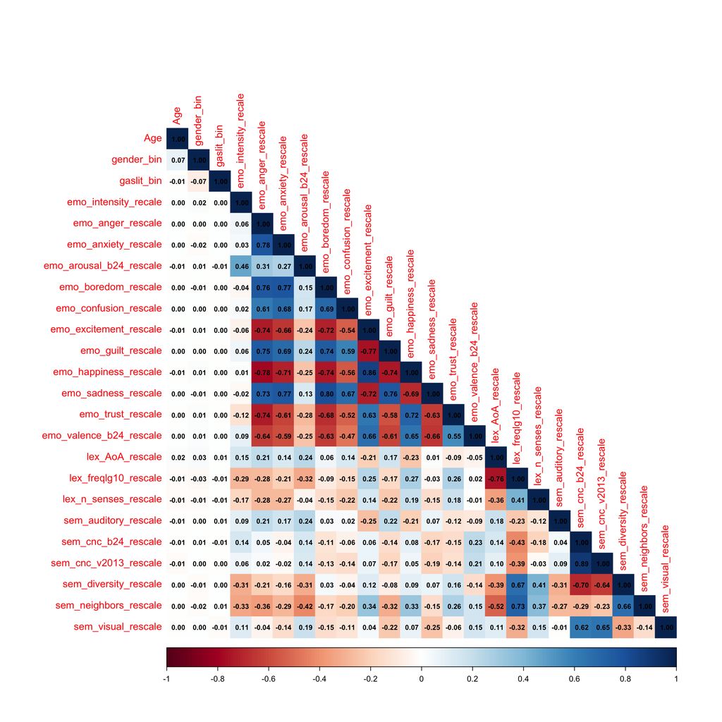

```r
library(corrplot)
# Make df for corr matrix
analysis_cor <- my_gaslight |>
  mutate(gender_bin = ifelse(Gender == "Male", 1, 0),
         gaslit_bin = ifelse(Ever_Gaslit == "Yes", 1, 0)) |>
  select(Age, gender_bin, gaslit_bin, emo_intensity_recale, ends_with("_rescale")) |>
  select(where(is.numeric))

# Corr matrix
cm <- cor(analysis_cor, use = "pairwise.complete.obs")
corrplot(cm, method = "color", type = "lower", addCoef.col = "black", number.cex = 0.7)
```

Okay from this, it looks like the most promising participant-level data to look at is gender (based on the max. |.03| correlation as opposed to the max. |.02| correlation for age and max |.01| for gaslighting history with our emotion, lexical, and semantic variables).

# New hypotheses:

Going to make my life #easier: I hypothesize 1) that words with a higher emotional intensity will be associated with a later age of acquistion and 2) higher lexical frequency in the recounted gaslight stories. I further predict that 3) gender will moderate these relationships.

```r
# New analysis df
analysis_df2 <- my_gaslight |>
  dplyr::select(ID, word_clean, emo_intensity_recale, Gender, lex_AoA_rescale, lex_freqlg10_rescale) |>
  dplyr::filter(!is.na(word_clean), word_clean != "",
                !is.na(emo_intensity_recale), emo_intensity_recale != "",
                !is.na(Gender), Gender != "",  # Blanks in df for some / not NAs
                !is.na(lex_AoA_rescale), lex_AoA_rescale != "",
                !is.na(lex_freqlg10_rescale), lex_freqlg10_rescale != "") |>
  dplyr::mutate(Gender = factor(Gender))
analysis_df2
```

```
## # A tibble: 41,235 × 6
##    ID    word_clean emo_intensity_recale[,1] Gender lex_AoA_rescale
##    <fct> <chr>                         <dbl> <fct>            <dbl>
##  1 814   student                       3.08  Female           1.68
##  2 814   harass                        8.70  Female           3.56
##  3 814   customer                      0.709 Female           2.16
##  4 814   say                           0.155 Female           0.707
##  5 814   stuff                         0.133 Female           1.31
##  6 814   back                          0.133 Female           1.43
##  7 814   customer                      0.709 Female           2.16
##  8 814   make                          0.155 Female           1.19
##  9 814   customer                      0.709 Female           2.16
## 10 814   much                          0.133 Female           1.15
## # ℹ 41,225 more rows
## # ℹ 1 more variable: lex_freqlg10_rescale <dbl>
```

```r
n_distinct(analysis_df2$ID)
```

```
## [1] 1002
```

Now we have 1002 subjects for these analyses. I also think I should center these values for interpretability…

```r
analysis_df2 <- analysis_df2 |>
  mutate(AoA_c= scale(lex_AoA_rescale, scale = FALSE), Freq_c = scale(lex_freqlg10_rescale, scale = FALSE))
```

## H6: Emotion intensity and AoA

```r
library(ggplot2)
H6 <- lmer(emo_intensity_recale ~ AoA_c + (1 | ID), data = analysis_df2)
summary(H6)
```

```
## Linear mixed model fit by REML. t-tests use Satterthwaite's method [
## lmerModLmerTest]
## Formula: emo_intensity_recale ~ AoA_c + (1 | ID)
##    Data: analysis_df2
##
## REML criterion at convergence: 169312.9
##
## Scaled residuals:
##     Min      1Q  Median      3Q     Max
## -1.4266 -0.5708 -0.4369  0.1177  4.3611
##
## Random effects:
##  Groups   Name        Variance Std.Dev.
##  ID       (Intercept) 0.0692   0.2631
##  Residual             3.5056   1.8723
## Number of obs: 41235, groups:  ID, 1002
##
## Fixed effects:
##              Estimate Std. Error        df t value Pr(>|t|)
## (Intercept) 1.289e+00  1.301e-02 8.914e+02   99.07   <2e-16 ***
## AoA_c       3.264e-01  1.159e-02 4.097e+04   28.16   <2e-16 ***
## ---
## Signif. codes:  0 '***' 0.001 '**' 0.01 '*' 0.05 '.' 0.1 ' ' 1
##
## Correlation of Fixed Effects:
##       (Intr)
## AoA_c 0.003
```

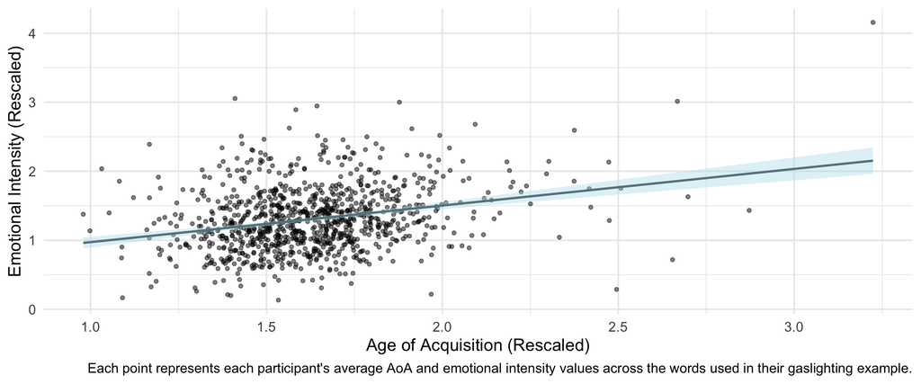

```r
# Make participant-level df for plot
analysis_avg <- analysis_df2 |>
  group_by(ID) |>
  summarise(emo_intensity = mean(emo_intensity_recale),
    AoA = mean(lex_AoA_rescale),
    Freq = mean(lex_freqlg10_rescale),
    .groups = "drop")

ggplot(analysis_avg,
       aes(x = AoA,
           y = emo_intensity)) +
  geom_point(alpha = .5, color = "black") +
  geom_smooth(method = "lm",
              color = "lightblue4",
              fill = "lightblue2",
              linewidth = 1) +
  labs(x = "Age of Acquisition (Rescaled)",
    y = "Emotional Intensity (Rescaled)",
    caption = "Each point represents each participant's average AoA and emotional intensity values across the words used in their gaslighting example.") +
  theme_minimal(base_size = 16)
```

There is a significant association between the age of acquisition and the emotional intensity of the words used in the gaslight example stories, such that words learned later in life were associated with higher emotional intensity, b = 0.33, t = 28.2, p < .001.